# Private education and English rugby

Alexander Lawless

17 August 2021

## Introduction

Small disclaimer to start: **I have a well developed inferiority complex when it comes to rugby in England**

As a state-school educated club rugby player throughout my youth, I played with and against privately educated affluent boys on many a Sunday morning. They were always seemed to be better than me! Big, physical, loud and very very confident. I'm clearly still bitter.

With a new-born baby and a subsequently subdued social life, I have been painstakingly googling players, checking their wikipedia and searching for club page profiles to identify each players highschool education type (state or private).

https://www.premiershiprugby.com/gallagher-premiership-rugby/fixtures-results/

Below is a short summary displaying the skewwed playing population of England's high level rugby players. A game for all shapes and sizes - not all social groups or education types.

## State or private education

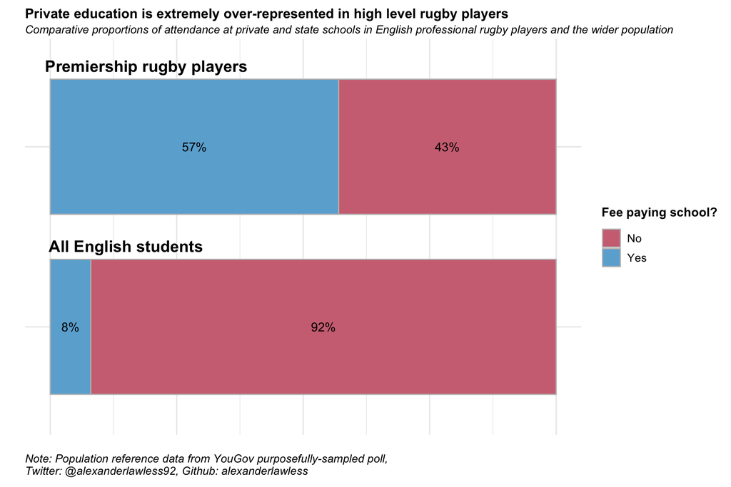

```r
players_education_summary_ref %>%
  ggplot(aes(x = name, y = value, fill = fee_paying, label = label)) +
  geom_col(width = 0.75, colour = "grey") +
  geom_text(aes(label = label), position = position_stack(vjust = 0.5)) +
  annotate("text", x = 2.45, y = 19, size = 5, fontface = 2,
           label = "Premiership rugby players") +
  annotate("text", x = 1.45, y = 15, size = 5, fontface= 2,
           label = "All English students") +
  coord_flip() +
  scale_fill_manual(values = c("#cf7282",
                               "#6baed6")) +
  theme(axis.text = element_blank()) +
  labs(x = "",
       y = "",
       fill = "Fee paying school?",
       title = "Private education is extremely over-represented in high level rugby players",
       subtitle = "Comparative proportions of attendance at private and state schools in English professional rugby players and the wider population ",
       caption = "Note: Population reference data from YouGov purposefully-sampled poll,
Twitter: @alexanderlawless92, Github: alexanderlawless")
```

Unfortunately, this result wasn't all that surprising to me and probably won't be for others. That is the problem.

Population reference data source: https://docs.cdn.yougov.com/sahadddz8r/Copy%20of%20Internal_Education_210125.pdf

## Sutton Trust data comparison

The Sutton Trust released the 'Elitist Britain' report in 2019, highlighting the educational backgrounds of Britain's leading people and industries.

https://www.suttontrust.com/our-research/elitist-britain-2019/

The below graph incorporates Sutton Trust data alongside that of the above graph for additional context.

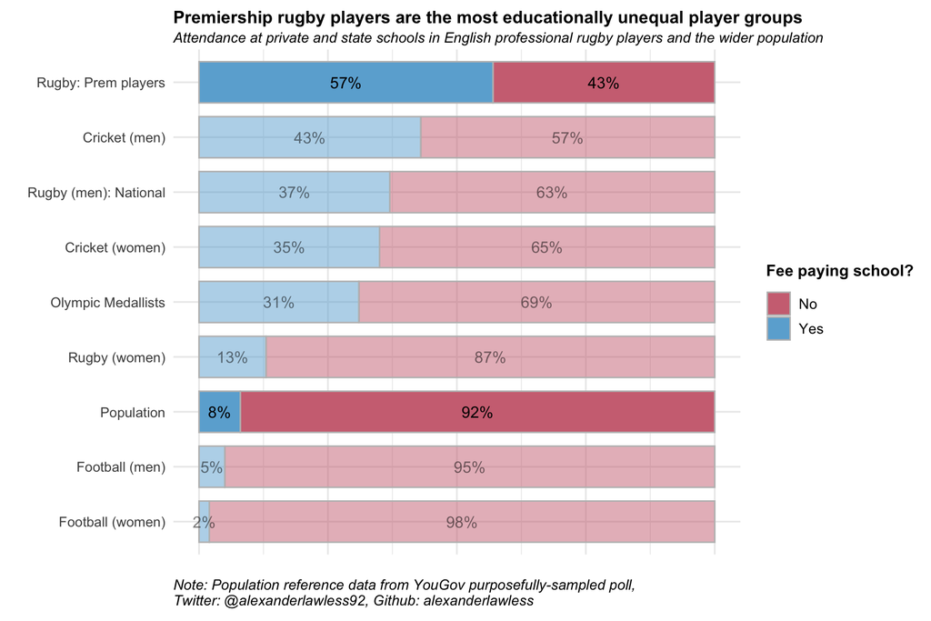

```r
education_comparason_sutton %>%
  ggplot(aes(x = reorder(name, -order),
             y = value,
             fill = fee_paying,
             label = label,
             alpha = alpha)) +
  geom_col(width = 0.75, colour = "grey") +
  geom_text(aes(label = label), position = position_stack(vjust = 0.5)) +
  # annotate("text", x = 2.45, y = 100, size = 3, fontface = 2, label = "Premiership rugby players") +
  coord_flip() +
  scale_alpha_manual(values = c(0.5, 1), guide = "none") +
  scale_fill_manual(values = c("#cf7282",
                               "#6baed6")) +
  theme(axis.text.x =  element_blank()) +
  labs(x = "",
       y = "",
       fill = "Fee paying school?",
       title = "Premiership rugby players are the most educationally unequal player groups",
       subtitle = "Attendance at private and state schools in English professional rugby players and the wider population",
       caption = "Note: Population reference data from YouGov purposefully-sampled poll,
Twitter: @alexanderlawless92, Github: alexanderlawless")
```

The proportion of privately educated players is higher in English Premiership players than the Sutton trust estimate of "Rugby (men) National" which considers the national teams of England, Scotland and Wales. Scotland and Wales have much more equitable entry routes into professional rugby and as such lower the proportion considerably.

## Private education by team

[figure not shown]

```r
fee_paying_proportion_by_team +
  inset_element(p = sale_img, left = 0.0,  right = 0.083, bottom = 0.80, top = 0.90) +
  inset_element(p = worcester_img, left = 0.083,  right = 0.1666, bottom = 0.80, top = 0.90) +
  inset_element(p = london_irish_img, left = 0.1666,  right = 0.2499, bottom = 0.80, top = 0.90) +
  inset_element(p = wasps_img, left = 0.2499,  right = 0.3332, bottom = 0.80, top = 0.90) +
  inset_element(p = bath_img, left = 0.3332,  right = 0.4165, bottom = 0.80, top = 0.90) +
  inset_element(p = gloucester_img, left = 0.4165,  right = 0.4998, bottom = 0.80, top = 0.90) +
  inset_element(p = northampton_img, left = 0.4998,  right = 0.5831, bottom = 0.80, top = 0.90) +
  inset_element(p = newcastle_img, left = 0.5831,  right = 0.6664, bottom = 0.80, top = 0.90) +
  inset_element(p = harlequins_img, left = 0.6664,  right = 0.7497, bottom = 0.80, top = 0.90) +
  inset_element(p = bristol_img, left = 0.7497,  right = 0.833, bottom = 0.80, top = 0.90) +
  inset_element(p = leicester_img, left = 0.833,  right = 0.9163, bottom = 0.80, top = 0.90) +
  inset_element(p = exeter_img, left = 0.9163,  right = 0.9996, bottom = 0.80, top = 0.90)
```

The proportion of privately educated players vary by team but all show vast over-representation of fee-paying education; this is most notable in Sale Sharks where near 75% of players are privately educated. This is not a feature of the local population of Sale and is likely a function of similar (or even exaggerated) educational inequities in professional rugby in South Africa, where a considerable number of Sale's players come from.

## Education types and position

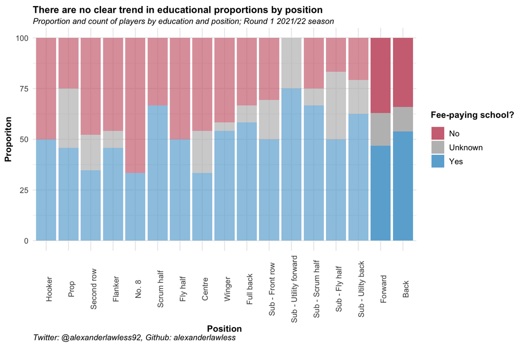

```r
# Education proportion by position
position_education_summary %>%
  group_by(position_desc) %>%
  mutate(prop = n/sum(n)*100) %>%
  select(position_desc, fee_paying, n, prop) %>%
  union(
    position_education_summary %>%
      group_by(forward_back, fee_paying) %>%
      summarise(n = sum(n)) %>%
      mutate(prop = n/sum(n)*100) %>%
      rename(position_desc = forward_back)
  ) %>%
  mutate(alpha =
           case_when(
             position_desc %in% c("Forward" , "Back") ~ "B",
             TRUE ~ "A"
           )) %>%
  ungroup() %>%
  mutate(position_desc = factor(position_desc, levels = c(
    "Hooker", "Prop", "Second row", "Flanker", "No. 8",
    "Scrum half", "Fly half", "Centre", "Winger", "Full back",
    "Sub - Front row", "Sub - Utility forward", "Sub - Scrum half",
    "Sub - Fly half", "Sub - Utilty back", "Forward", "Back")
    )) %>%

  ggplot(aes(x = position_desc, y = prop, fill = fee_paying, label = n, alpha = alpha)) +
  geom_col(position = "stack") +
  theme(axis.text.x = element_text(angle = 90)) +
  scale_fill_manual(values = c("#cf7282",
                               "728ecf",
                               "#6baed6")) +
  #geom_text(position = position_stack(vjust = 0.5)) +
  scale_alpha_manual(values = c(0.7, 1), guide = "none") +
  labs(x = "Position",
       y = "Proporiton",
       fill = "Fee-paying school?",
       title = "There are no clear trend in educational proportions by position",
       subtitle = "Proportion and count of players by education and position; Round 1 2021/22 season",
       caption = "Twitter: @alexanderlawless92, Github: alexanderlawless")
```

## Education profile and league standing

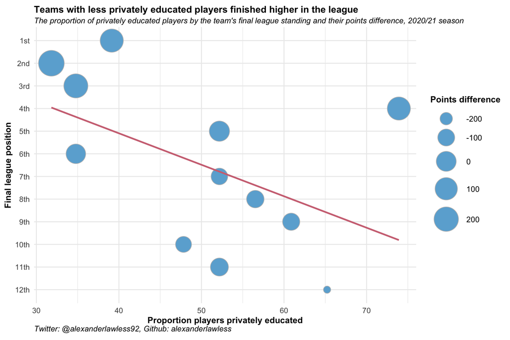

```r
proportion_by_standing %>%
  ggplot(aes(x = prop, y = final_standing_2, group = 1)) +
  geom_point(aes(size = points_diff),fill = "#6baed6", colour = "grey", pch = 21) +
  geom_smooth(method = "lm", se = FALSE, colour = "#cf7282") +
  scale_size_continuous(range = c(4, 15)) +
  labs(x = "Proportion players privately educated",
       y = "Final league position",
       size = "Points difference",
       title = "Teams with less privately educated players finished higher in the league",
       subtitle = "The proportion of privately educated players by the team's final league standing and their points difference, 2020/21 season",
       caption = "Twitter: @alexanderlawless92, Github: alexanderlawless")
```